# (노트) Pytorch CNN (MNIST 3,7)

Oct 21, 2021 • 신록예찬 • 20 min read

빅데이터분석

- import
- data
- 모형 (기존모형)
- 선형변환 대신에 2d convolution with windowsize=5
- ReLU() 대신에 MaxPool2d + ReLU
- maxpooling
  - ReLU
- 이제 그냥 시그모이드에 태우자!!
- networks 설계
- 드랍아웃, 배치추가 (fastai + 내가만든네트워크)
  - step1: dls를 만들자
  - step2: 아키텍처, 손실함수, 옵티마이저
  - step3: lrnr 생성
- resnet34를 사용
  - 결과관찰
- 설명가능한 모형?
  - net1은 유지+ net2는 구조를 바꾼다!!
  - CAM: observation을 1개로 고정하고 net2에서 layer의 순서를 바꿔서 시각화
- 숙제

### import

```python
import torch
from fastai.vision.all import *
```

```python
import graphviz
```

```python
def gv(s): return graphviz.Source('digraph G{ rankdir="LR"' + s + '; }')
```

### data

`-` download data

```python
path = untar_data(URLs.MNIST_SAMPLE)
```

```python
path.ls()
```

```
(#3) [Path('/home/cgb3/.fastai/data/mnist_sample/labels.csv'),Path('/home/cgb3/.fastai/data/mnist_sample/valid'),Path('/home/cgb3/.fastai/data/mnist_sample/train')]
```

`-` list

```python
threes=(path/'train'/'3').ls()
sevens=(path/'train'/'7').ls()
```

`-` list $\to$ image

```python
Image.open(threes[0])
```

[output not shown]

`-` image $\to$ tensor

```python
tensor(Image.open(threes[0]))
```

```
tensor([[  0,   0,   0,   0,   0,   0,   0,   0,   0,   0,   0,   0,   0,   0,
           0,   0,   0,   0,   0,   0,   0,   0,   0,   0,   0,   0,   0,   0],
        [  0,   0,   0,   0,   0,   0,   0,   0,   0,   0,   0,   0,   0,   0,
           0,   0,   0,   0,   0,   0,   0,   0,   0,   0,   0,   0,   0,   0],
        [  0,   0,   0,   0,   0,   0,   0,   0,   0,   0,   0,   0,   0,   0,
           0,   0,   0,   0,   0,   0,   0,   0,   0,   0,   0,   0,   0,   0],
        [  0,   0,   0,   0,   0,   0,   0,   0,   0,   0,   0,   0,   0,   0,
           0,   0,   0,   0,   0,   0,   0,   0,   0,   0,   0,   0,   0,   0],
        [  0,   0,   0,   0,   0,   0,   0,   0,   0,   0,   0,   0,   0,   0,
           0,   0,   0,   0,   0,   0,   0,   0,   0,   0,   0,   0,   0,   0],
        [  0,   0,   0,   0,   0,   0,   0,   0,   0,   0,   0,   0,   0,   0,
           0,   0,   0,   0,   0,   0,   0,   0,   0,   0,   0,   0,   0,   0],
        [  0,   0,   0,   0,   0,   0,   0,   0,  31, 105, 105, 105, 105, 192,
         255, 253, 253, 253, 253, 253, 253, 113,  25,   0,   0,   0,   0,   0],
        [  0,   0,   0,   0,   0,  85, 208, 208, 221, 252, 252, 252, 252, 252,
         253, 252, 252, 252, 252, 252, 252, 252,  59,   0,   0,   0,   0,   0],
        [  0,   0,   0,   0,   0, 208, 252, 252, 252, 250, 245, 252, 240, 237,
         238, 237, 237, 244, 252, 252, 252, 252,  59,   0,   0,   0,   0,   0],
        [  0,   0,   0,   0,   0, 110, 132, 132, 132, 118,  71, 132,  31,   0,
           0,   0,   8, 182, 252, 252, 252, 252,  59,   0,   0,   0,   0,   0],
        [  0,   0,   0,   0,   0,   0,   0,   0,   0,   0,   0,   0,   0,   0,
           0,  62, 173, 252, 252, 252, 252, 128,   7,   0,   0,   0,   0,   0],
        [  0,   0,   0,   0,   0,   0,   0,   0,   0,   0,   0,   0,   0,  18,
         179, 239, 252, 252, 252, 230, 142,   4,   0,   0,   0,   0,   0,   0],
        [  0,   0,   0,   0,   0,   0,   0,   0,   0,   0,   0,   0, 104, 203,
         253, 252, 252, 252, 252,  74,   0,   0,   0,   0,   0,   0,   0,   0],
        [  0,   0,   0,   0,   0,   0,   0,   0,   0,  11, 168, 238, 248, 252,
         253, 252, 252, 252, 252, 224,  42,   0,   0,   0,   0,   0,   0,   0],
        [  0,   0,   0,   0,   0,   0,   0,  22,  89, 200, 252, 252, 252, 252,
         253, 252, 249, 228, 252, 252, 221,  11,   0,   0,   0,   0,   0,   0],
        [  0,   0,   0,   0,   0,   0,   0, 120, 252, 252, 252, 252, 252, 252,
         104, 103,  97,  49, 235, 252, 252,  14,   0,   0,   0,   0,   0,   0],
        [  0,   0,   0,   0,   0,   0,   0,  71, 241, 253, 197, 149,  35,   0,
           0,   0,   0,   0, 136, 253, 253,  76,   0,   0,   0,   0,   0,   0],
        [  0,   0,   0,   0,   0,   0,   0,   0,  39,  44,  21,   0,   0,   0,
           0,   0,   0,  29, 230, 252, 252,  40,   0,   0,   0,   0,   0,   0],
        [  0,   0,   0,   0,   0,   0,   0,   0,   0,   0,   0,   0,   0,   0,
           0,   0,   1, 128, 252, 252, 252,  14,   0,   0,   0,   0,   0,   0],
        [  0,   0,   0,   0,   0,   0,   0,   0,   0,   0,   0,   0,   0,   0,
           0,  29, 128, 252, 252, 252, 188,   8,   0,   0,   0,   0,   0,   0],
        [  0,   0,   0,   0,   0,   0,   0,   0,   0,   0,   0,   0,   0,   0,
          31, 117, 252, 252, 252, 181,  14,   0,   0,   0,   0,   0,   0,   0],
        [  0,   0,   0,   0,   0,   0,   0,   0,   0,   0,   0,   0,   0,  18,
         210, 252, 252, 252, 243,  65,   0,   0,   0,   0,   0,   0,   0,   0],
        [  0,   0,   0,   0,   0,   0,   8, 134, 134, 134, 134, 134, 134, 203,
         253, 252, 252, 252,  99,   0,   0,   0,   0,   0,   0,   0,   0,   0],
        [  0,   0,   0,   0,   0,  22, 187, 252, 252, 252, 252, 252, 252, 252,
         253, 230, 162,  92,   2,   0,   0,   0,   0,   0,   0,   0,   0,   0],
        [  0,   0,   0,   0,   0,  60, 252, 252, 252, 252, 252, 252, 252, 252,
         208,  70,   0,   0,   0,   0,   0,   0,   0,   0,   0,   0,   0,   0],
        [  0,   0,   0,   0,   0,  25, 199, 252, 207, 103, 103, 103, 103, 103,
           0,   0,   0,   0,   0,   0,   0,   0,   0,   0,   0,   0,   0,   0],
        [  0,   0,   0,   0,   0,   0,   0,   0,   0,   0,   0,   0,   0,   0,
           0,   0,   0,   0,   0,   0,   0,   0,   0,   0,   0,   0,   0,   0],
        [  0,   0,   0,   0,   0,   0,   0,   0,   0,   0,   0,   0,   0,   0,
           0,   0,   0,   0,   0,   0,   0,   0,   0,   0,   0,   0,   0,   0]],
       dtype=torch.uint8)
```

- tensor는 fastai에서 구현한 함수. 리턴값은 파이토치에서 우리가 쓰던 그 텐서

`-` 여러개를 처리하여보자.

```python
seven_tensor = torch.stack([tensor(Image.open(i)) for i in sevens]).float()/255
three_tensor = torch.stack([tensor(Image.open(i)) for i in threes]).float()/255
```

`-` $X$와 $y$를 만들자.

```python
seven_tensor.shape, three_tensor.shape
```

```
(torch.Size([6265, 28, 28]), torch.Size([6131, 28, 28]))
```

```python
y=torch.tensor([0.0]*6265 + [1.0]*6131).reshape(12396,1)
```

```python
X=torch.vstack([seven_tensor,three_tensor])
```

```python
X=X.reshape(12396,28*28)
```

```python
X.shape
```

```
torch.Size([12396, 784])
```

```python
y.shape
```

```
torch.Size([12396, 1])
```

### 모형 (기존모형)

`-` 교재의 모형

```python
gv('''
splines=line
subgraph cluster_1{
    style=filled;
    color=lightgrey;
    "x1"
    "x2"
    ".."
    "x784"
    label = "Layer 0"
}
subgraph cluster_2{
    style=filled;
    color=lightgrey;
    "x1" -> "node1"
    "x2" -> "node1"
    ".." -> "node1"

    "x784" -> "node1"
    "x1" -> "node2"
    "x2" -> "node2"
    ".." -> "node2"
    "x784" -> "node2"

    "x1" -> "..."
    "x2" -> "..."
    ".." -> "..."
    "x784" -> "..."

    "x1" -> "node30"
    "x2" -> "node30"
    ".." -> "node30"
    "x784" -> "node30"


    label = "Layer 1: ReLU"
}
subgraph cluster_3{
    style=filled;
    color=lightgrey;
    "node1" -> "y"
    "node2" -> "y"
    "..." -> "y"
    "node30" -> "y"
    label = "Layer 2: Sigmoid"
}
''')
```

[figure not shown]

`-` 왜 28$\times$28 이미지를 784개의 벡터로 만든 다음에 모형을 돌려야 하는가?

`-` 기존에 개발된 모형이 회귀분석기반으로 되어있어서 결국 회귀분석 틀에 짜맞춰서 이미지자료를 분석하고 있는 꼴

`-` observation의 차원은 $1\times 784$가 아니라 $1\times (28\times 28)$이 되어야 맞다.

```python
X.shape
```

```
torch.Size([12396, 784])
```

```python
X=X.reshape(12396,1,28,28)
```

```python
X.shape
```

```
torch.Size([12396, 1, 28, 28])
```

```python
plt.imshow(X[0][0]) # 777 observation, first channel
```

[output not shown]

### 선형변환 대신에 2d convolution with windowsize=5

```python
c1=torch.nn.Conv2d(1,16,5) #입력채널=1: 흑백이니까, 아웃풋채널=16
```

```python
c1(X).shape
```

```
torch.Size([12396, 16, 24, 24])
```

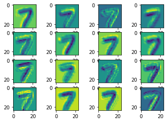

```python
fig, axs = plt.subplots(4,4)
k=0
for i in range(4):
    for j in range(4):
        axs[i,j].imshow(c1(X)[0][k].data)
        k=k+1
```

```python
fig.set_figheight(8)
fig.set_figwidth(8)
fig.tight_layout()
```

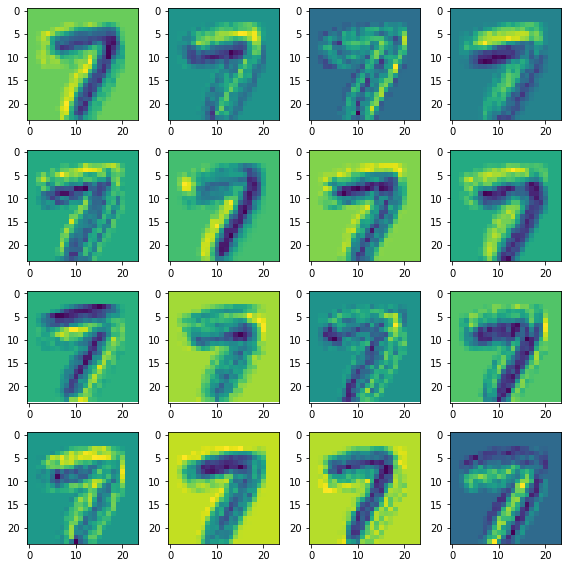

```python
fig
```

### ReLU() 대신에 MaxPool2d + ReLU

### maxpooling

```python
m1=torch.nn.MaxPool2d(2)
```

```python
c1(X).shape,m1(c1(X)).shape
```

```
(torch.Size([12396, 16, 24, 24]), torch.Size([12396, 16, 12, 12]))
```

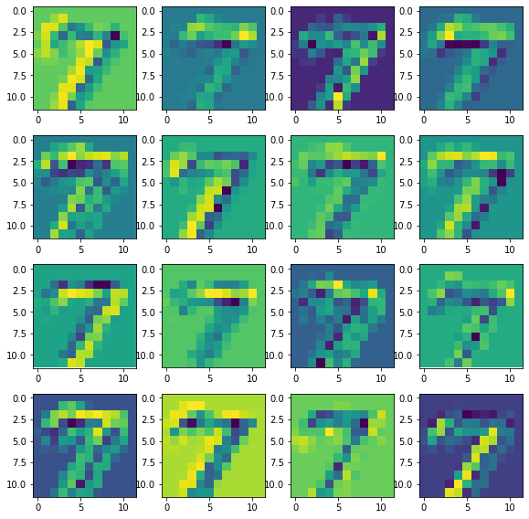

```python
fig, axs = plt.subplots(4,4)
k=0
for i in range(4):
    for j in range(4):
        axs[i,j].imshow(m1(c1(X))[776][k].data)
        k=k+1
fig.set_figheight(8)
fig.set_figwidth(8)
fig.tight_layout()
```

#### ReLU

```python
a1=nn.ReLU()
```

```python
c1(X).shape,m1(c1(X)).shape,a1(m1(c1(X))).shape
```

```
(torch.Size([12396, 16, 24, 24]),
 torch.Size([12396, 16, 12, 12]),
 torch.Size([12396, 16, 12, 12]))
```

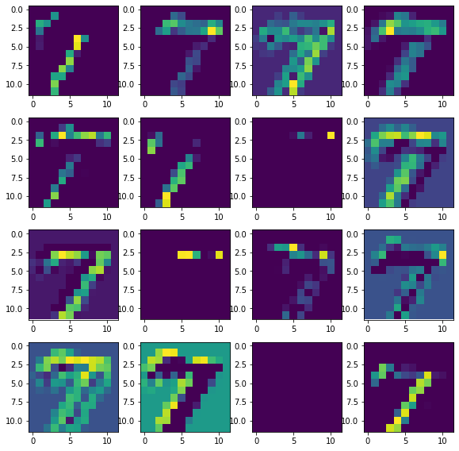

```python
fig, axs = plt.subplots(4,4)
k=0
for i in range(4):
    for j in range(4):
        axs[i,j].imshow(a1(m1(c1(X)))[776][k].data)
        k=k+1
fig.set_figheight(8)
fig.set_figwidth(8)
fig.tight_layout()
```

```python
torch.manual_seed(1)
_A=torch.randn(3,3)
_A
```

```
tensor([[ 0.6614,  0.2669,  0.0617],
        [ 0.6213, -0.4519, -0.1661],
        [-1.5228,  0.3817, -1.0276]])
```

```python
a1(_A)
```

```
tensor([[0.6614, 0.2669, 0.0617],
        [0.6213, 0.0000, 0.0000],
        [0.0000, 0.3817, 0.0000]])
```

### 이제 그냥 시그모이드에 태우자!!

`-` 현재상황

```python
a1(m1(c1(X))).shape
```

```
torch.Size([12396, 16, 12, 12])
```

`-` 펼치자

```python
a1(m1(c1(X))).reshape(12396,-1).shape
```

```
torch.Size([12396, 2304])
```

`-` 일단 2304 저 디멘젼을 1로 만들어야겠음

```python
l1=torch.nn.Linear(in_features=2304, out_features=1)
l1(a1(m1(c1(X))).reshape(12396,-1))
```

```
tensor([[-0.0295],
        [ 0.0176],
        [-0.0579],
        ...,
        [-0.0053],
        [-0.0876],
        [-0.0275]], grad_fn=<AddmmBackward0>)
```

`-` 시그모이드를 태우자.

```python
a2=torch.nn.Sigmoid()
a2(l1(a1(m1(c1(X))).reshape(12396,-1)))
```

```
tensor([[0.4926],
        [0.5044],
        [0.4855],
        ...,
        [0.4987],
        [0.4781],
        [0.4931]], grad_fn=<SigmoidBackward0>)
```

### networks 설계

```python
net=torch.nn.Sequential(
    c1, # 컨볼루션 (선형)
    m1, # 맥스풀링 (비선형) -- 효과? 나중에 다룰것: 이미지를 계층적으로 파악함
    a1, # 렐루 (비선형)


    a1(m1(c1(X))).reshape(12396,-1), ## 이걸어떻게구현하지?


    l1) # 선형변환
## 마지막의 a2는 생략한다. 손실함수에 이미 내장되어 있으므로
```

```
---------------------------------------------------------------------------
TypeError                                 Traceback (most recent call last)
/tmp/ipykernel_4181556/1636364211.py in <module>
----> 1 net=torch.nn.Sequential(
      2     c1, # 컨볼루션 (선형)
      3     m1, # 맥스풀링 (비선형) -- 효과? 나중에 다룰것: 이미지를 계층적으로 파악함
      4     a1, # 렐루 (비선형)
      5

~/anaconda3/envs/py38r40/lib/python3.8/site-packages/torch/nn/modules/container.py in __init__(self, *args)
     89         else:
     90             for idx, module in enumerate(args):
---> 91                 self.add_module(str(idx), module)
     92
     93     def _get_item_by_idx(self, iterator, idx) -> T:

~/anaconda3/envs/py38r40/lib/python3.8/site-packages/torch/nn/modules/module.py in add_module(self, name, module)
    375         """
    376         if not isinstance(module, Module) and module is not None:
--> 377             raise TypeError("{} is not a Module subclass".format(
    378                 torch.typename(module)))
    379         elif not isinstance(name, torch._six.string_classes):

TypeError: torch.FloatTensor is not a Module subclass
```

```python
net=torch.nn.Sequential(
    c1, # 컨볼루션 (선형)
    m1, # 맥스풀링 (비선형) -- 효과? 나중에 다룰것: 이미지를 계층적으로 파악함
    a1, # 렐루 (비선형)


#    a1(m1(c1(X))).reshape(12396,-1), ## 이걸어떻게구현하지?


    l1) # 선형변환
## 마지막의 a2는 생략한다. 손실함수에 이미 내장되어 있으므로.
```

결국 주석처리한 부분을 구현해야함.

`-` `c1`, `m1` ,`a1` ,`l1` 의 공통점?

- 무언가를 상속받는 클래스에서 생성된 인스턴스이다.
- forward 메소드가 있다.

`-` `c1`, `m1` ,`a1` ,`l1` 과 같은 레이어를 만드는 방법? (custom layer를 만드는 방법)

- torch.nn.Module을 상속받아서 클래스를 하나 만든다.
- forward 메소드를 정의한다. (다음층으로 리턴할 값)

```python
class Flatten(torch.nn.Module):
    def forward(self,x):
        return x.reshape(12396,-1)
```

```python
flatten=Flatten()
```

```python
a1(m1(c1(X))).shape
```

```
torch.Size([12396, 16, 12, 12])
```

```python
flatten(a1(m1(c1(X)))).shape
```

```
torch.Size([12396, 2304])
```

`-` 잘구현된것 같다! 이제 다시 네트워크를 만들자.

```python
net=torch.nn.Sequential(
    c1, # 컨볼루션 (선형)
    m1, # 맥스풀링 (비선형) -- 효과? 나중에 다룰것: 이미지를 계층적으로 파악함
    a1, # 렐루 (비선형)
    flatten, # a1(m1(c1(X))).reshape(12396,-1), ## 이걸어떻게구현하지?
    l1) # 선형변환
## 마지막의 a2는 생략한다. 손실함수에 이미 내장되어 있으므로
```

`-` 손실함수와 옵티마이저 정의

```python
loss_fn=torch.nn.BCEWithLogitsLoss()
optimizer = torch.optim.Adam(net.parameters())
```

`-` step 1~4

```python
for epoc in range(200):
    ## 1
    yhat=net(X)
    ## 2
    loss= loss_fn(yhat,y)
    ## 3
    loss.backward()
    ## 4
    optimizer.step()
    net.zero_grad()
```

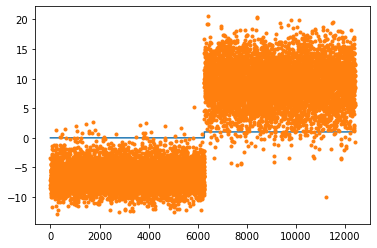

```python
plt.plot(y)
plt.plot(yhat.data,'.')
```

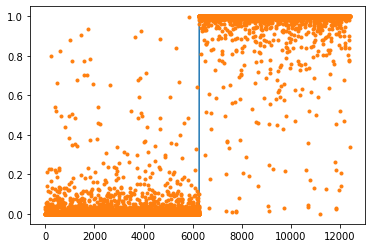

```python
plt.plot(y)
plt.plot(a2(yhat.data),'.')
```

```python
ypred= a2(yhat.data)>0.5
```

```python
sum(ypred==y)/12396
```

```
tensor([0.9934])
```

`-` 좀 더 좋아졌다.. (이미 좋았는데 더 좋아짐)

### 드랍아웃, 배치추가 (fastai + 내가만든네트워크)

#### step1: dls를 만들자

```python
ds=torch.utils.data.TensorDataset(X,y)
```

```python
ds.tensors[0].shape
```

```
torch.Size([12396, 1, 28, 28])
```

```python
ds1,ds2=torch.utils.data.random_split(ds, [10000, 2396])
```

```python
dl1=torch.utils.data.DataLoader(ds1,batch_size=500)
dl2=torch.utils.data.DataLoader(ds2,batch_size=2396)
```

```python
dls=DataLoaders(dl1,dl2)
```

#### step2: 아키텍처, 손실함수, 옵티마이저

`-` 네트워크 수정

```python
class Flatten(torch.nn.Module):
    def forward(self,x):
        return x.reshape(x.shape[0],-1)
```

```python
flatten=Flatten()
```

```python
net=torch.nn.Sequential(
    torch.nn.Conv2d(1,16,5),
    torch.nn.MaxPool2d(2),
    torch.nn.ReLU(),
    torch.nn.Dropout2d(), ## 드랍아웃도 넣었다
    flatten,
    torch.nn.Linear(in_features=2304,out_features=1)
)
```

#### step3: lrnr 생성

```python
lrnr1=Learner(dls,net,opt_func=Adam,loss_func=loss_fn)
```

```python
lrnr1.fit(10) # 멀 얼마나 맞추는거야???
```

| epoch | train_loss | valid_loss | time |
| --- | --- | --- | --- |
| 0 | 0.039963 | 0.028925 | 00:00 |
| 1 | 0.039958 | 0.027841 | 00:00 |
| 2 | 0.038759 | 0.026731 | 00:00 |
| 3 | 0.038265 | 0.025684 | 00:00 |
| 4 | 0.036585 | 0.025383 | 00:00 |
| 5 | 0.035487 | 0.023996 | 00:00 |
| 6 | 0.034868 | 0.022751 | 00:00 |
| 7 | 0.034449 | 0.022461 | 00:00 |
| 8 | 0.033623 | 0.020992 | 00:00 |
| 9 | 0.032664 | 0.020993 | 00:00 |

```python
lrnr1.model
```

```
Sequential(
  (0): Conv2d(1, 16, kernel_size=(5, 5), stride=(1, 1))
  (1): MaxPool2d(kernel_size=2, stride=2, padding=0, dilation=1, ceil_mode=False)
  (2): ReLU()
  (3): Dropout2d(p=0.5, inplace=False)
  (4): Flatten()
  (5): Linear(in_features=2304, out_features=1, bias=True)
)
```

`-` 각 모델에 접근하려면 아래와 같이

```python
lrnr1.model[0]
```

```
Conv2d(1, 16, kernel_size=(5, 5), stride=(1, 1))
```

```python
lrnr1.model[1]
```

```
MaxPool2d(kernel_size=2, stride=2, padding=0, dilation=1, ceil_mode=False)
```

`-` 출력

```python
print(X.shape, '---> 입력')
print(lrnr1.model[0](X.to("cuda:0")).shape, '---> 2d 컨볼루션')
print(lrnr1.model[1](lrnr1.model[0](X.to("cuda:0"))).shape, '---> 맥스풀링')
print(lrnr1.model[2](lrnr1.model[1](lrnr1.model[0](X.to("cuda:0")))).shape, '---> 렐루')
print(lrnr1.model[3](lrnr1.model[2](lrnr1.model[1](lrnr1.model[0](X.to("cuda:0"))))).shape, '---> 드랍아웃')
print(lrnr1.model[4](lrnr1.model[3](lrnr1.model[2](lrnr1.model[1](lrnr1.model[0](X.to("cuda:0")))))).shape, '---> 플래튼')
print(lrnr1.model[5](lrnr1.model[4](lrnr1.model[3](lrnr1.model[2](lrnr1.model[1](lrnr1.model[0](X.to("cuda:0"))))))).shape, '---> 리니어')
```

```
torch.Size([12396, 1, 28, 28]) ---> 입력
torch.Size([12396, 16, 24, 24]) ---> 2d 컨볼루션
torch.Size([12396, 16, 12, 12]) ---> 맥스풀링
torch.Size([12396, 16, 12, 12]) ---> 렐루
torch.Size([12396, 16, 12, 12]) ---> 드랍아웃
torch.Size([12396, 2304]) ---> 플래튼
torch.Size([12396, 1]) ---> 리니어
```

`-` 최종적으로는 아래와 같이 된다.

```python
lrnr1.model[5](lrnr1.model[4](lrnr1.model[3](lrnr1.model[2](lrnr1.model[1](lrnr1.model[0](X.to("cuda:0")))))))
```

```
tensor([[-9.6808],
        [-7.2376],
        [-6.7483],
        ...,
        [-1.5702],
        [ 6.4246],
        [11.0522]], device='cuda:0', grad_fn=<AddmmBackward0>)
```

`-` 그냥 아래처럼 간편하게 해도된다.

```python
lrnr1.model(X.to("cuda:0"))
```

```
tensor([[-9.6808],
        [-7.2376],
        [-6.7483],
        ...,
        [-1.5702],
        [ 6.4246],
        [11.0522]], device='cuda:0', grad_fn=<AddmmBackward0>)
```

```python
lrnr1.model(X.to("cuda:0")).data
```

```
tensor([[-9.6808],
        [-7.2376],
        [-6.7483],
        ...,
        [-1.5702],
        [ 6.4246],
        [11.0522]], device='cuda:0')
```

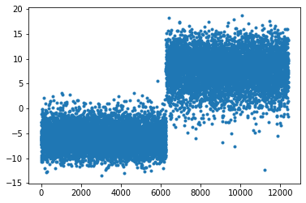

```python
plt.plot(lrnr1.model(X.to("cuda:0")).to("cpu").data,'.')
```

`-` 빠르고 괜찮다!

### resnet34를 사용

`-` fastai로 할 예정이다.

`-` 아까의 dls는 내가 만든 네트워크에 특화되었음. $\to$ 네트워크의 형태에 따라서 dls의 형태도 다르게 만들어야 함.

- 내가만든 MLP를 생각해보면 첫입력이 $784 \to ???$ 인 선형층이었음
- 내가만든 CNN을 생각해보면 첫입력이 $1\times 28 \times 28 \to ???$ 로 가는 2Dconv 였음

`-` dls는 네트워크의 아키텍처에 따라서 다르게 만들어 져야함. (당연한소리)

`-` resnet34라는 네트워크를 사용하기 이해서 새로운 dls를 만들자.

```python
path = untar_data(URLs.MNIST_SAMPLE)
```

```python
dls2=ImageDataLoaders.from_folder(
    path,
    train='train',
    valid_pct=0.2)
```

```python
lrnr2=cnn_learner(dls2,resnet34,metrics=error_rate)
```

```python
lrnr2.fine_tune(1)
```

| epoch | train_loss | valid_loss | error_rate | time |
| --- | --- | --- | --- | --- |
| 0 | 0.290497 | 0.148596 | 0.047817 | 00:06 |

| epoch | train_loss | valid_loss | error_rate | time |
| --- | --- | --- | --- | --- |
| 0 | 0.045010 | 0.021780 | 0.006584 | 00:06 |

`-` 현재 state of the art라 평가받는 resnet34의 네트워크 구경

```python
lrnr2.model
```

```
Sequential(
  (0): Sequential(
    (0): Conv2d(3, 64, kernel_size=(7, 7), stride=(2, 2), padding=(3, 3), bias=False)
    (1): BatchNorm2d(64, eps=1e-05, momentum=0.1, affine=True, track_running_stats=True)
    (2): ReLU(inplace=True)
    (3): MaxPool2d(kernel_size=3, stride=2, padding=1, dilation=1, ceil_mode=False)
    (4): Sequential(
      (0): BasicBlock(
        (conv1): Conv2d(64, 64, kernel_size=(3, 3), stride=(1, 1), padding=(1, 1), bias=False)
        (bn1): BatchNorm2d(64, eps=1e-05, momentum=0.1, affine=True, track_running_stats=True)
        (relu): ReLU(inplace=True)
        (conv2): Conv2d(64, 64, kernel_size=(3, 3), stride=(1, 1), padding=(1, 1), bias=False)
        (bn2): BatchNorm2d(64, eps=1e-05, momentum=0.1, affine=True, track_running_stats=True)
      )
      (1): BasicBlock(
        (conv1): Conv2d(64, 64, kernel_size=(3, 3), stride=(1, 1), padding=(1, 1), bias=False)
        (bn1): BatchNorm2d(64, eps=1e-05, momentum=0.1, affine=True, track_running_stats=True)
        (relu): ReLU(inplace=True)
        (conv2): Conv2d(64, 64, kernel_size=(3, 3), stride=(1, 1), padding=(1, 1), bias=False)
        (bn2): BatchNorm2d(64, eps=1e-05, momentum=0.1, affine=True, track_running_stats=True)
      )
      (2): BasicBlock(
        (conv1): Conv2d(64, 64, kernel_size=(3, 3), stride=(1, 1), padding=(1, 1), bias=False)
        (bn1): BatchNorm2d(64, eps=1e-05, momentum=0.1, affine=True, track_running_stats=True)
        (relu): ReLU(inplace=True)
        (conv2): Conv2d(64, 64, kernel_size=(3, 3), stride=(1, 1), padding=(1, 1), bias=False)
        (bn2): BatchNorm2d(64, eps=1e-05, momentum=0.1, affine=True, track_running_stats=True)
      )
    )
    (5): Sequential(
      (0): BasicBlock(
        (conv1): Conv2d(64, 128, kernel_size=(3, 3), stride=(2, 2), padding=(1, 1), bias=False)
        (bn1): BatchNorm2d(128, eps=1e-05, momentum=0.1, affine=True, track_running_stats=True)
        (relu): ReLU(inplace=True)
        (conv2): Conv2d(128, 128, kernel_size=(3, 3), stride=(1, 1), padding=(1, 1), bias=False)
        (bn2): BatchNorm2d(128, eps=1e-05, momentum=0.1, affine=True, track_running_stats=True)
        (downsample): Sequential(
          (0): Conv2d(64, 128, kernel_size=(1, 1), stride=(2, 2), bias=False)
          (1): BatchNorm2d(128, eps=1e-05, momentum=0.1, affine=True, track_running_stats=True)
        )
```

[output cut: 99 more lines]

```
  (1): Sequential(
    (0): AdaptiveConcatPool2d(
      (ap): AdaptiveAvgPool2d(output_size=1)
      (mp): AdaptiveMaxPool2d(output_size=1)
    )
    (1): Flatten(full=False)
    (2): BatchNorm1d(1024, eps=1e-05, momentum=0.1, affine=True, track_running_stats=True)
    (3): Dropout(p=0.25, inplace=False)
    (4): Linear(in_features=1024, out_features=512, bias=False)
    (5): ReLU(inplace=True)
    (6): BatchNorm1d(512, eps=1e-05, momentum=0.1, affine=True, track_running_stats=True)
    (7): Dropout(p=0.5, inplace=False)
    (8): Linear(in_features=512, out_features=2, bias=False)
  )
)
```

`-` 관찰결과

- 네트워크는 우리와 유사하게 net1(2d계층),net2(1d계층)로 구성된다.
- 입력채널이 3 (실제로는 흑백이미지인데 칼라이미지로 생각) $\to$ DLS를 따로 만들어야 했던 이유. 우리가 설계한 네트워크는 입력채널이 1이었음.
- 컨볼루션에 옵션이 다양해보임. (stride, padding)
- net1에서는 Dropout 대신에 BatchNormalization 사용, net2에서는 드랍아웃사용.
- net2의 마지막에서 out_features=2이다. 즉 2차원이 반환된다. 이는 활성화함수를 Sigmoid 대신에 Softmax를 사용한다는 의미.

#### 결과관찰

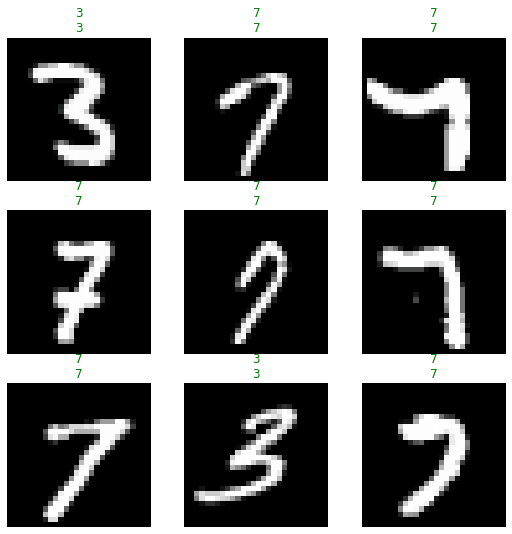

```python
lrnr2.show_results()
```

- 너무 잘맞춤..

### 설명가능한 모형?

`-` 현재까지의 모형

- 1단계: 2d 선형변환 + 2d 비선형변환
- 2단계: Flatten $\to$ MLP

`-` 1단계의 결과는 아래와 같다.

```python
lrnr1.model
```

```
Sequential(
  (0): Conv2d(1, 16, kernel_size=(5, 5), stride=(1, 1))
  (1): MaxPool2d(kernel_size=2, stride=2, padding=0, dilation=1, ceil_mode=False)
  (2): ReLU()
  (3): Dropout2d(p=0.5, inplace=False)
  (4): Flatten()
  (5): Linear(in_features=2304, out_features=1, bias=True)
)
```

- 위의 모형을 0~3까지 순차적으로 적용하면 된다.

```python
net1=torch.nn.Sequential(
    lrnr1.model[0],
    lrnr1.model[1],
    lrnr1.model[2],
    lrnr1.model[3])
```

```python
net1(X.to('cuda:0')).shape
```

```
torch.Size([12396, 16, 12, 12])
```

`-` 1단계까지의 출력은 아래와 같다.

```python
net1(X.to('cuda:0'))[0][0].to('cpu').data
```

```
tensor([[5.6614e-03, 5.6614e-03, 5.6614e-03, 5.6614e-03, 5.6614e-03, 5.6614e-03,
         5.6614e-03, 5.6614e-03, 5.6614e-03, 5.6614e-03, 5.6614e-03, 5.6614e-03],
        [5.6614e-03, 5.6614e-03, 5.6614e-03, 4.1945e-02, 1.6052e-01, 2.5874e-01,
         3.8027e-01, 4.9269e-01, 4.3673e-01, 1.8436e-01, 2.9746e-02, 5.6614e-03],
        [5.6614e-03, 1.6305e-01, 3.9514e-01, 5.4750e-01, 9.0676e-01, 1.2231e+00,
         1.3511e+00, 1.5250e+00, 1.5863e+00, 1.1000e+00, 3.0866e-01, 5.6614e-03],
        [5.6614e-03, 1.0868e-01, 9.3733e-01, 1.7305e+00, 1.8306e+00, 1.9910e+00,
         1.8542e+00, 2.0425e+00, 2.1507e+00, 1.7403e+00, 4.3269e-01, 5.6614e-03],
        [5.6614e-03, 1.2679e-01, 1.0677e+00, 1.6961e+00, 1.6779e+00, 1.6607e+00,
         1.5945e+00, 1.7356e+00, 2.0451e+00, 1.8034e+00, 3.8948e-01, 5.6614e-03],
        [5.6614e-03, 0.0000e+00, 6.1002e-01, 9.7776e-01, 8.8203e-01, 5.7707e-01,
         4.8905e-01, 1.1585e+00, 1.9467e+00, 1.5821e+00, 1.6449e-01, 5.6614e-03],
        [5.6614e-03, 5.6614e-03, 5.6614e-03, 2.3344e-01, 1.6647e-01, 1.0777e-01,
         6.3508e-01, 1.9244e+00, 1.9435e+00, 1.0594e+00, 3.1491e-02, 5.6614e-03],
        [5.6614e-03, 5.6614e-03, 5.6614e-03, 5.6614e-03, 1.1394e-01, 5.5022e-01,
         1.3059e+00, 1.9424e+00, 1.5534e+00, 2.3055e-01, 5.6614e-03, 5.6614e-03],
        [5.6614e-03, 5.6614e-03, 5.6614e-03, 4.1945e-02, 1.7900e-01, 1.0149e+00,
         1.9873e+00, 1.7555e+00, 1.0770e+00, 3.6072e-02, 5.6614e-03, 5.6614e-03],
        [5.6614e-03, 5.6614e-03, 5.6614e-03, 6.5847e-02, 5.9066e-01, 1.6443e+00,
         2.0309e+00, 1.4126e+00, 1.1521e-01, 5.6614e-03, 5.6614e-03, 5.6614e-03],
        [5.6614e-03, 5.6614e-03, 5.6614e-03, 8.3880e-02, 8.4303e-01, 1.9407e+00,
         1.7305e+00, 7.1511e-01, 1.8576e-02, 5.6614e-03, 5.6614e-03, 5.6614e-03],
        [5.6614e-03, 5.6614e-03, 5.6614e-03, 3.3044e-05, 8.2147e-01, 1.7639e+00,
         1.3854e+00, 1.1591e-01, 5.6614e-03, 5.6614e-03, 5.6614e-03, 5.6614e-03]])
```

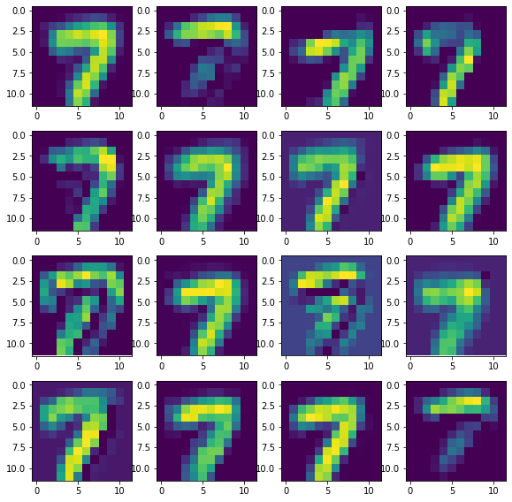

```python
fig, axs = plt.subplots(4,4)
k=0
for i in range(4):
    for j in range(4):
        axs[i,j].imshow(net1(X.to('cuda:0'))[0][k].to('cpu').data) # 1번째 obs, k번째 채널
        k=k+1
fig.set_figheight(8)
fig.set_figwidth(8)
fig.tight_layout()
```

#### net1은 유지+ net2는 구조를 바꾼다!!

`-` 계획

- 변경전: (n,16,12,12) $\overset{flatten}{\Longrightarrow}$ (n,?) $\overset{linear(?,1)}{\Longrightarrow}$ (n,1)
- 변경후: (n,16,12,12) $\overset{gap+flatten}{\Longrightarrow}$ (n,16) $\overset{linear(16,1)}{\Longrightarrow}$ (n,1)

`-` gap: 12 $\times$ 12 픽셀을 평균내서 하나의 값으로 대표하자. (왜??)

```python
ap=torch.nn.AdaptiveAvgPool2d(output_size=1)
```

```python
ap(net1(X.to('cuda:0'))).shape
```

```
torch.Size([12396, 16, 1, 1])
```

*보충학습: ap는 그냥 평균*

```python
torch.tensor([[0.1,0.2],[0.3,0.4]])
```

```
tensor([[0.1000, 0.2000],
        [0.3000, 0.4000]])
```

```python
ap(torch.tensor([[0.1,0.2],[0.3,0.4]]))
```

```
tensor([[0.2500]])
```

`-` flatten: 이제 플래튼함수를 재활용하여 차원축소

```python
flatten(ap(net1(X.to('cuda:0')))).shape
```

```
torch.Size([12396, 16])
```

`-` linear

```python
_l1=torch.nn.Linear(16,1,bias=False)
```

```python
_l1.to('cuda:0')
```

```
Linear(in_features=16, out_features=1, bias=False)
```

```python
_l1(flatten(ap(net1(X.to('cuda:0')))))
```

```
tensor([[-0.0129],
        [-0.0248],
        [-0.0112],
        ...,
        [-0.0221],
        [-0.0396],
        [-0.0423]], device='cuda:0', grad_fn=<MmBackward0>)
```

`-` 이걸 net2로 구성하자. $\to$ (net1,net2)를 묶어 하나의 네트워크로 다시 만들자.

```python
net2=torch.nn.Sequential(
    torch.nn.AdaptiveAvgPool2d(1),
    Flatten(),
    torch.nn.Linear(16,1,bias=False)
)
```

```python
net=torch.nn.Sequential(net1,net2)
net
```

```
Sequential(
  (0): Sequential(
    (0): Conv2d(1, 16, kernel_size=(5, 5), stride=(1, 1))
    (1): MaxPool2d(kernel_size=2, stride=2, padding=0, dilation=1, ceil_mode=False)
    (2): ReLU()
    (3): Dropout2d(p=0.5, inplace=False)
  )
  (1): Sequential(
    (0): AdaptiveAvgPool2d(output_size=1)
    (1): Flatten()
    (2): Linear(in_features=16, out_features=1, bias=False)
  )
)
```

`-` 수정된 네트워크로 lrnr3를 만들고 재학습

```python
ds=torch.utils.data.TensorDataset(X,y)
ds1,ds2 = torch.utils.data.random_split(ds,[10000,2396])
dl1=torch.utils.data.DataLoader(ds1,batch_size=1000)
dl2=torch.utils.data.DataLoader(ds2,batch_size=2396)
dls=DataLoaders(dl1,dl2)
```

```python
lrnr3=Learner(dls,net,opt_func=Adam,loss_func=loss_fn,lr=0.1)
```

```python
lrnr3.fit(10)
```

| epoch | train_loss | valid_loss | time |
| --- | --- | --- | --- |
| 0 | 0.709154 | 0.690176 | 00:00 |
| 1 | 0.697847 | 0.688962 | 00:00 |
| 2 | 0.693645 | 0.687055 | 00:00 |
| 3 | 0.690929 | 0.682808 | 00:00 |
| 4 | 0.687271 | 0.673825 | 00:00 |
| 5 | 0.682103 | 0.656035 | 00:00 |
| 6 | 0.675339 | 0.634298 | 00:00 |
| 7 | 0.666364 | 0.615474 | 00:00 |
| 8 | 0.657003 | 0.603212 | 00:00 |
| 9 | 0.648347 | 0.590276 | 00:00 |

#### CAM: observation을 1개로 고정하고 net2에서 layer의 순서를 바꿔서 시각화

`-` 계획

`-` 준비과정1: 시각화할 샘플을 하나 준비하자.

```python
x=X[0]
X.shape,x.shape
```

```
(torch.Size([12396, 1, 28, 28]), torch.Size([1, 28, 28]))
```

- 차원이 다르므로 나중에 네트워크에 넣을때 문제가 생길수 있다 $\to$ 우선 차원을 맞춰주자

```python
x=x.reshape(1,1,28,28)
```

```python
plt.imshow(x.squeeze()) #plt.imshow(x)
```

[output not shown]

- 준비된 샘플은 7이 그려진 이미지

`-` 준비과정2: 계산을 위해서 각 네트워크를 cpu로 옮겨두자. (fastai로 학습한 직후라 GPU에 있을것임)

```python
net1.to('cpu')
net2.to('cpu')
```

```
Sequential(
  (0): AdaptiveAvgPool2d(output_size=1)
  (1): Flatten()
  (2): Linear(in_features=16, out_features=1, bias=False)
)
```

`-` forward 확인: 이 값을 기억하자!

```python
net2(net1(x)) ## 음수이므로 class=7
```

```
tensor([[-0.9974]], grad_fn=<MmBackward0>)
```

`-` net2를 수정하고 forward값 확인

```python
net2
```

```
Sequential(
  (0): AdaptiveAvgPool2d(output_size=1)
  (1): Flatten()
  (2): Linear(in_features=16, out_features=1, bias=False)
)
```

- net2에서 Linear와 AdaptiveAvgPool2의 적용순서를 바꿔줌

차원확인

```python
net1(x).squeeze().shape
```

```
torch.Size([16, 12, 12])
```

```python
net2[2].weight.squeeze().shape
```

```
torch.Size([16])
```

Linear(in_features=16, out_features=1, bias=False) 먼저 적용: 16 $\times$ (16,12,12) $\to$ (1,12,12)

```python
net2[2].weight.squeeze() @ net1(x).squeeze()
```

```
---------------------------------------------------------------------------
RuntimeError                              Traceback (most recent call last)
/tmp/ipykernel_4181556/674153214.py in <module>
----> 1 net2[2].weight.squeeze() @ net1(x).squeeze()

RuntimeError: mat1 and mat2 shapes cannot be multiplied (192x12 and 16x1)
```

- 실패..

```python
camimg=torch.einsum('i,ijk -> jk',net2[-1].weight.squeeze(),net1(x).squeeze())
```

- 성공

AdaptiveAvgPool2d(output_size=1) 를 적용

```python
ap(camimg)
```

```
tensor([[-0.9974]], grad_fn=<MeanBackward1>)
```

`!!!!` 똑같다?

`-` 아래의 값이 같다.

```python
net2(net1(x)), ap(camimg)
```

```
(tensor([[-0.9974]], grad_fn=<MmBackward0>),
 tensor([[-0.9974]], grad_fn=<MeanBackward1>))
```

`-` 왜냐하면 ap와 선형변환 모두 linear이기 떄문에 순서를 바꿔도 상관없음

`-` 아래와 결국 같은 이치

```python
_x = np.array([1,2,3,4])
_x
```

```
array([1, 2, 3, 4])
```

```python
np.mean(_x*2+1)
```

```
6.0
```

```python
2*np.mean(_x)+1
```

```
6.0
```

`-` 결국

- 16개의 2D이미지 $\to$ 선형변환 $\to$ 평균
- 16개의 2D이미지 $\to$ 평균 $\to$ 선형변환

은 같다.

`-` 이제 camimg에 관심을 가져보자.

```python
camimg
```

```
tensor([[  0.0000,   0.0000,   0.0000,   0.0000,   0.0000,   0.0000,   0.0000,
           0.0000,   0.0000,   0.0000,   0.0000,   0.0000],
        [  0.0000,   0.0000,   0.0000,   0.0000,   0.0000,   0.0000,   0.0000,
           0.0000,   0.0000,   0.0000,   0.0000,   0.0000],
        [  0.0000,  -0.0578,   0.0000,   0.0000,   0.0000,   0.0000,   0.0000,
           0.0000,   0.0000,   0.0000,   0.0000,   0.0000],
        [  0.0000,  -0.8865,   0.0000,   0.0000,   0.0000,   0.0000,   0.0000,
           0.0000,   0.0000,   0.0000,   0.0000,   0.0000],
        [  0.0000,  -1.1274,   0.0000,   0.0000,   0.0000,   0.0000,   0.0000,
           0.0000,   0.0000,   0.0000,   0.0000,   0.0000],
        [  0.0000,   0.0000,   0.0000,   0.0000,   0.0000,   0.0000,  -4.1321,
           0.0000,   0.0000,   0.0000,   0.0000,   0.0000],
        [  0.0000,   0.0000,   0.0000,   0.0000,   0.0000,  -1.1217, -28.6904,
           0.0000,   0.0000,   0.0000,   0.0000,   0.0000],
        [  0.0000,   0.0000,   0.0000,   0.0000,  -0.6852, -14.3085, -10.8387,
           0.0000,   0.0000,   0.0000,   0.0000,   0.0000],
        [  0.0000,   0.0000,   0.0000,   0.0000,  -8.2556, -17.8891,   0.0000,
           0.0000,   0.0000,   0.0000,   0.0000,   0.0000],
        [  0.0000,   0.0000,   0.0000,  -0.3799, -23.6879,   0.0000,   0.0000,
           0.0000,   0.0000,   0.0000,   0.0000,   0.0000],
        [  0.0000,   0.0000,   0.0000,  -2.4046, -20.2352,   0.0000,   0.0000,
           0.0000,   0.0000,   0.0000,   0.0000,   0.0000],
        [  0.0000,   0.0000,   0.0000,  -2.1762,  -6.7481,   0.0000,   0.0000,
           0.0000,   0.0000,   0.0000,   0.0000,   0.0000]],
       grad_fn=<ViewBackward0>)
```

```python
ap(camimg), torch.mean(camimg)
```

```
(tensor([[-0.9974]], grad_fn=<MeanBackward1>),
 tensor(-0.9974, grad_fn=<MeanBackward0>))
```

- 이미지의 값은 대부분0이지만 궁극적으로는 평균을 내서 음수의 값이 나와야한다.

`-` 결국 특정 픽셀에서 큰 음의 값이 나오기 때문에 궁극적으로 평균이 음수가 된다.

- 평균이 음수이다 $\leftrightarrow$ 이미지가 의미하는 것이 7이다.
- 특정 픽셀이 큰 음수값을 가진다. $\leftrightarrow$ 그 픽셀에서 이미지가 7임을 뚜렷하게 알 수 있다.

`-` 그 특정픽셀이 어딘가?

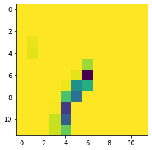

```python
plt.imshow(camimg.data)
```

- 초록색으로 표현된 부분은 CNN모형이 이 숫자를 7이라고 생각한 근거가 된다. ($\star\star\star$)

`-` 원래의 이미지와 비교

```python
plt.imshow(x.squeeze())
```

[output not shown]

`-` 두 이미지를 겹쳐서 그리면 멋진 그림이 될것 같다.

step1: 원래이미지를 흑백으로 그리자.

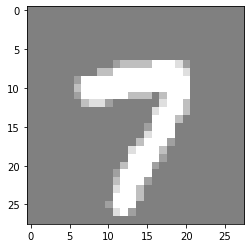

```python
plt.imshow(x.squeeze(),cmap='gray',alpha=0.5)
```

`-` step2: 원래이미지는 (28,28)인데 camimg는 (12,12)픽셀이다. $\to$ camimg의 픽셀을 늘리자!

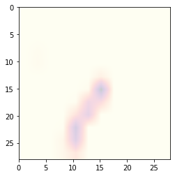

```python
plt.imshow(camimg.data,alpha=0.2,extent=(0,28,28,0),interpolation='bilinear',cmap='magma')
```

`-` step3: 합치자.

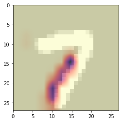

```python
plt.imshow(x.squeeze(),cmap='gray',alpha=0.5)
plt.imshow(camimg.data,alpha=0.6,extent=(0,27,27,0),interpolation='bilinear',cmap='magma')
```

### 숙제

`-` 숫자3이 그려진 이미지를 observation으로 선택하고 위와 같이 cam을 이용하여 시각화 하라.